# Spotify Project-Copy1

## The Billboard #1 Track

The Billboard Hot 100 is the music industry standard record chart in the United States for songs, published weekly by Billboard magazine.

Factors that are used to calculate the Billboard Top Tracks

1. Sales (Physical and Digital)
2. Radio Play
3. Online Streaming Data

I scraped this data from Wikipedia's list of Billboard #1 Tracks from 2010 - 2019 https://en.wikipedia.org/wiki/Billboard_Hot_100

## The Spotify Magic

Spotify has been a leader in enabling discovery of new music. The company uses audio analysis models to extract features about the song - how danceable it is, how energetic it is, among other things. They use these features to robustly predict what songs a person is more likely to love.

Lucky for us, Spotify gives access to their API here https://developer.spotify.com/

## API Calls

Spotipy is a sweet Python package that makes it easy to connect

We'll be primarily using two Spotify API endpoints

1. Search - takes in a search string and outputs matching songs
2. Audio Features - takes in a song URL and outputs the audio features of track

```python
import spotipy
import spotipy.util as util
from spotipy.oauth2 import SpotifyClientCredentials

cid = 'e33f0325007b4844bb2d8b79a15f94c1'
secret = 'c4e8f9c0404f4aafa1ef2786d4d2a58d'
client_credentials_manager = SpotifyClientCredentials(client_id=cid, client_secret=secret)
sp = spotipy.Spotify(client_credentials_manager = client_credentials_manager)


import pandas as pd
import numpy as np
import matplotlib.pyplot as plt
import seaborn as sns
import json
from fbprophet import Prophet
from sklearn.metrics import mean_squared_error

pd.set_option('display.max_columns', None)
pd.set_option('display.max_rows', None)
```

## Loading the Billboard Decade 2010-2020 data

### Sourced from Wikipedia

```python
billboard = pd.read_csv('billboardtop.csv', parse_dates=["date"])
billboard.head()
```

|  | id | date | artist | song | weeks | link |
| --- | --- | --- | --- | --- | --- | --- |
| 0 | 1041 | 2015-01-17 | Mark Ronson featuring Bruno Mars | "Uptown Funk"♪ [70] | 14 | [71] |
| 1 | 1042 | 2015-04-25 | Wiz Khalifa featuring Charlie Puth | "See You Again" | 12 | [72] |
| 2 | 1043 | 2015-06-06 | Taylor Swift featuring Kendrick Lamar | "Bad Blood" | 1 | [73] |
| 3 | 1044 | 2015-07-25 | Omi | "Cheerleader" | 6 | [74] |
| 4 | 1045 | 2015-08-22 | The Weeknd | "Can't Feel My Face" | 3 | [75] |

```python
#Cleaning up
billboard['song'] = billboard['song'].apply(lambda x: x.split('"')[1])
billboard['aSearch'] = billboard['artist'].apply(lambda x : " ".join(x.split(" ")[:2]))
billboard['year'] = billboard['date'].dt.year
billboard['searcher'] = billboard['song'] + " " + billboard['aSearch']
```

```python
billboard.head()
```

|  | id | date | artist | song | weeks | link | aSearch | year | searcher |
| --- | --- | --- | --- | --- | --- | --- | --- | --- | --- |
| 0 | 1041 | 2015-01-17 | Mark Ronson featuring Bruno Mars | Uptown Funk | 14 | [71] | Mark Ronson | 2015 | Uptown Funk Mark Ronson |
| 1 | 1042 | 2015-04-25 | Wiz Khalifa featuring Charlie Puth | See You Again | 12 | [72] | Wiz Khalifa | 2015 | See You Again Wiz Khalifa |
| 2 | 1043 | 2015-06-06 | Taylor Swift featuring Kendrick Lamar | Bad Blood | 1 | [73] | Taylor Swift | 2015 | Bad Blood Taylor Swift |
| 3 | 1044 | 2015-07-25 | Omi | Cheerleader | 6 | [74] | Omi | 2015 | Cheerleader Omi |
| 4 | 1045 | 2015-08-22 | The Weeknd | Can't Feel My Face | 3 | [75] | The Weeknd | 2015 | Can't Feel My Face The Weeknd |

#### Using the 'search' API Call to find the songs in our Billboard list - on Spotify

```python
#Example
sp.search('See You Again')
```

```python
def getTrackURI(searcher):
    result = sp.search(searcher)
    try:
        obj1 = result['tracks']['items'][0]['uri']

    except:
        obj1 = None
    return obj1

def getArtists(searcher):
    result = sp.search(searcher)
    try:
        obj2 = result['tracks']['items'][0]['artists']
        names = []
        for name in obj2:
            names.append(name['name'])
        obj2 = ",".join(names)
    except:
        obj2 = ""
    return obj2



billboard['uri'] = billboard['searcher'].apply(getTrackURI)
billboard['artists'] = billboard['searcher'].apply(getArtists)

billboard = billboard.dropna()
billboard.head()
```

```
retrying ...2secs
```

|  | id | date | artist | song | weeks | link | aSearch | year | searcher | uri | artists |
| --- | --- | --- | --- | --- | --- | --- | --- | --- | --- | --- | --- |
| 0 | 1041 | 2015-01-17 | Mark Ronson featuring Bruno Mars | Uptown Funk | 14 | [71] | Mark Ronson | 2015 | Uptown Funk Mark Ronson | spotify:track:32OlwWuMpZ6b0aN2RZOeMS | Mark Ronson,Bruno Mars |
| 1 | 1042 | 2015-04-25 | Wiz Khalifa featuring Charlie Puth | See You Again | 12 | [72] | Wiz Khalifa | 2015 | See You Again Wiz Khalifa | spotify:track:2JzZzZUQj3Qff7wapcbKjc | Wiz Khalifa,Charlie Puth |
| 2 | 1043 | 2015-06-06 | Taylor Swift featuring Kendrick Lamar | Bad Blood | 1 | [73] | Taylor Swift | 2015 | Bad Blood Taylor Swift | spotify:track:273dCMFseLcVsoSWx59IoE | Taylor Swift |
| 3 | 1044 | 2015-07-25 | Omi | Cheerleader | 6 | [74] | Omi | 2015 | Cheerleader Omi | spotify:track:023OVLNzXhX0j7CxswUt6D | OMI |
| 4 | 1045 | 2015-08-22 | The Weeknd | Can't Feel My Face | 3 | [75] | The Weeknd | 2015 | Can't Feel My Face The Weeknd | spotify:track:22VdIZQfgXJea34mQxlt81 | The Weeknd |

### Now let's extract the audio features provided by Spotify for these songs

**danceability**: Danceability describes how suitable a track is for dancing based on a combination of musical elements including tempo, rhythm stability, beat strength, and overall regularity. A value of 0.0 is least danceable and 1.0 is most danceable.

**energy** Energy is a measure from 0.0 to 1.0 and represents a perceptual measure of intensity and activity. Typically, energetic tracks feel fast, loud, and noisy. For example, death metal has high energy, while a Bach prelude scores low on the scale. Perceptual features contributing to this attribute include dynamic range, perceived loudness, timbre, onset rate, and general entropy.

**liveness** float Detects the presence of an audience in the recording. Higher liveness values represent an increased probability that the track was performed live. A value above 0.8 provides strong likelihood that the track is live.

**loudness** float The overall loudness of a track in decibels (dB). Loudness values are averaged across the entire track and are useful for comparing relative loudness of tracks. Loudness is the quality of a sound that is the primary psychological correlate of physical strength (amplitude). Values typical range between -60 and 0 db.

**mode** int Mode indicates the modality (major or minor) of a track, the type of scale from which its melodic content is derived. Major is represented by 1 and minor is 0.

**speechiness** float Speechiness detects the presence of spoken words in a track. The more exclusively speech-like the recording (e.g. talk show, audio book, poetry), the closer to 1.0 the attribute value. Values above 0.66 describe tracks that are probably made entirely of spoken words. Values between 0.33 and 0.66 describe tracks that may contain both music and speech, either in sections or layered, including such cases as rap music. Values below 0.33 most likely represent music and other non-speech-like tracks.

**tempo** The overall estimated tempo of a track in beats per minute (BPM). In musical terminology, tempo is the speed or pace of a given piece and derives directly from the average beat duration.

**valence** A measure from 0.0 to 1.0 describing the musical positiveness conveyed by a track. Tracks with high valence sound more positive (e.g. happy, cheerful, euphoric), while tracks with low valence sound more negative (e.g. sad, depressed, angry).

```python
audio_features = []
for uri in billboard['uri'].values:
    audio_features.append(sp.audio_features(uri)[0])
```

```python
audio_features = pd.DataFrame(audio_features)[['danceability', 'energy', 'key', 'loudness', 'mode', 'speechiness',
                             'acousticness', 'liveness', 'valence', 'tempo', 'duration_ms', 'time_signature']]
audio_features['duration'] = audio_features['duration_ms']/60000
audio_features.head()
```

|  | danceability | energy | key | loudness | mode | speechiness | acousticness | liveness | valence | tempo | duration_ms | time_signature | duration |
| --- | --- | --- | --- | --- | --- | --- | --- | --- | --- | --- | --- | --- | --- |
| 0 | 0.856 | 0.609 | 0 | -7.223 | 1 | 0.0824 | 0.00801 | 0.0344 | 0.928 | 114.988 | 269667 | 4 | 4.494450 |
| 1 | 0.689 | 0.481 | 10 | -7.503 | 1 | 0.0815 | 0.36900 | 0.0649 | 0.283 | 80.025 | 229526 | 4 | 3.825433 |
| 2 | 0.652 | 0.802 | 7 | -6.114 | 1 | 0.1810 | 0.08710 | 0.1480 | 0.295 | 170.157 | 211933 | 4 | 3.532217 |
| 3 | 0.780 | 0.680 | 4 | -6.081 | 1 | 0.0305 | 0.14100 | 0.1380 | 0.594 | 118.026 | 180560 | 4 | 3.009333 |
| 4 | 0.705 | 0.769 | 9 | -5.526 | 0 | 0.0426 | 0.11200 | 0.1050 | 0.590 | 107.939 | 213520 | 4 | 3.558667 |

#### Let's engineer a few more features

**Season**

```python
billboard['year'] = billboard['date'].dt.year
billboard['month'] = billboard['date'].dt.month

def season(month):
    if month in [4, 5, 6]:
        return 'Spring'
    elif month in [7, 8, 9]:
        return 'Summer'
    elif month in [10, 11, 12]:
        return 'Fall'
    else:
        return 'Winter'

billboard['season'] = billboard['month'].apply(season)
```

```python
billDf = pd.concat([billboard, audio_features], axis=1)[['song', 'id', 'artists','date','year','season', 'artist', 'weeks','danceability', 'energy',
                                                'key', 'loudness', 'mode', 'speechiness',
                             'acousticness', 'liveness', 'valence', 'tempo', 'duration', 'time_signature', 'uri' ]]
```

```python
billDf.head()
```

|  | song | id | artists | date | year | season | artist | weeks | danceability | energy | key | loudness | mode | speechiness | acousticness | liveness | valence | tempo | duration | time_signature | uri |
| --- | --- | --- | --- | --- | --- | --- | --- | --- | --- | --- | --- | --- | --- | --- | --- | --- | --- | --- | --- | --- | --- |
| 0 | Uptown Funk | 1041.0 | Mark Ronson,Bruno Mars | 2015-01-17 | 2015.0 | Winter | Mark Ronson featuring Bruno Mars | 14.0 | 0.856 | 0.609 | 0.0 | -7.223 | 1.0 | 0.0824 | 0.00801 | 0.0344 | 0.928 | 114.988 | 4.494450 | 4.0 | spotify:track:32OlwWuMpZ6b0aN2RZOeMS |
| 1 | See You Again | 1042.0 | Wiz Khalifa,Charlie Puth | 2015-04-25 | 2015.0 | Spring | Wiz Khalifa featuring Charlie Puth | 12.0 | 0.689 | 0.481 | 10.0 | -7.503 | 1.0 | 0.0815 | 0.36900 | 0.0649 | 0.283 | 80.025 | 3.825433 | 4.0 | spotify:track:2JzZzZUQj3Qff7wapcbKjc |
| 2 | Bad Blood | 1043.0 | Taylor Swift | 2015-06-06 | 2015.0 | Spring | Taylor Swift featuring Kendrick Lamar | 1.0 | 0.652 | 0.802 | 7.0 | -6.114 | 1.0 | 0.1810 | 0.08710 | 0.1480 | 0.295 | 170.157 | 3.532217 | 4.0 | spotify:track:273dCMFseLcVsoSWx59IoE |
| 3 | Cheerleader | 1044.0 | OMI | 2015-07-25 | 2015.0 | Summer | Omi | 6.0 | 0.780 | 0.680 | 4.0 | -6.081 | 1.0 | 0.0305 | 0.14100 | 0.1380 | 0.594 | 118.026 | 3.009333 | 4.0 | spotify:track:023OVLNzXhX0j7CxswUt6D |
| 4 | Can't Feel My Face | 1045.0 | The Weeknd | 2015-08-22 | 2015.0 | Summer | The Weeknd | 3.0 | 0.705 | 0.769 | 9.0 | -5.526 | 0.0 | 0.0426 | 0.11200 | 0.1050 | 0.590 | 107.939 | 3.558667 | 4.0 | spotify:track:22VdIZQfgXJea34mQxlt81 |

#### A song with a valence (sentiment) higher than 0.5 can be assumed to be a 'happy' song

#### Since acousticness is the confidence that a song is acoustic, we can assume values of acousticness above 0.5 to refer to acoustic tracks

#### The documentation says rap songs have a speechiness between 0.33 and 0.66

```python
billDf['happy'] = billDf['valence'] >= 0.5
billDf['acoustic'] = billDf['acousticness'] >= 0.5
billDf['rap'] = (billDf['speechiness'] >=0.33) & (billDf['speechiness'] <=0.66)
```

```python
def tidy_split(df, column, sep='|', keep=False):
    indexes = list()
    new_values = list()
    df = df.dropna(subset=[column])
    for i, presplit in enumerate(df[column].astype(str)):
        values = presplit.split(sep)
        if keep and len(values) > 1:
            indexes.append(i)
            new_values.append(presplit)
        for value in values:
            indexes.append(i)
            new_values.append(value)
    new_df = df.iloc[indexes, :].copy()
    new_df[column] = new_values
    return new_df

artists = tidy_split(billDf, 'artists', ',').dropna()
artists.head(6)
```

|  | song | id | artists | date | year | season | artist | weeks | danceability | energy | key | loudness | mode | speechiness | acousticness | liveness | valence | tempo | duration | time_signature | uri | happy | acoustic | rap |
| --- | --- | --- | --- | --- | --- | --- | --- | --- | --- | --- | --- | --- | --- | --- | --- | --- | --- | --- | --- | --- | --- | --- | --- | --- |
| 0 | Uptown Funk | 1041.0 | Mark Ronson | 2015-01-17 | 2015.0 | Winter | Mark Ronson featuring Bruno Mars | 14.0 | 0.856 | 0.609 | 0.0 | -7.223 | 1.0 | 0.0824 | 0.00801 | 0.0344 | 0.928 | 114.988 | 4.494450 | 4.0 | spotify:track:32OlwWuMpZ6b0aN2RZOeMS | True | False | False |
| 0 | Uptown Funk | 1041.0 | Bruno Mars | 2015-01-17 | 2015.0 | Winter | Mark Ronson featuring Bruno Mars | 14.0 | 0.856 | 0.609 | 0.0 | -7.223 | 1.0 | 0.0824 | 0.00801 | 0.0344 | 0.928 | 114.988 | 4.494450 | 4.0 | spotify:track:32OlwWuMpZ6b0aN2RZOeMS | True | False | False |
| 1 | See You Again | 1042.0 | Wiz Khalifa | 2015-04-25 | 2015.0 | Spring | Wiz Khalifa featuring Charlie Puth | 12.0 | 0.689 | 0.481 | 10.0 | -7.503 | 1.0 | 0.0815 | 0.36900 | 0.0649 | 0.283 | 80.025 | 3.825433 | 4.0 | spotify:track:2JzZzZUQj3Qff7wapcbKjc | False | False | False |
| 1 | See You Again | 1042.0 | Charlie Puth | 2015-04-25 | 2015.0 | Spring | Wiz Khalifa featuring Charlie Puth | 12.0 | 0.689 | 0.481 | 10.0 | -7.503 | 1.0 | 0.0815 | 0.36900 | 0.0649 | 0.283 | 80.025 | 3.825433 | 4.0 | spotify:track:2JzZzZUQj3Qff7wapcbKjc | False | False | False |
| 2 | Bad Blood | 1043.0 | Taylor Swift | 2015-06-06 | 2015.0 | Spring | Taylor Swift featuring Kendrick Lamar | 1.0 | 0.652 | 0.802 | 7.0 | -6.114 | 1.0 | 0.1810 | 0.08710 | 0.1480 | 0.295 | 170.157 | 3.532217 | 4.0 | spotify:track:273dCMFseLcVsoSWx59IoE | False | False | False |
| 3 | Cheerleader | 1044.0 | OMI | 2015-07-25 | 2015.0 | Summer | Omi | 6.0 | 0.780 | 0.680 | 4.0 | -6.081 | 1.0 | 0.0305 | 0.14100 | 0.1380 | 0.594 | 118.026 | 3.009333 | 4.0 | spotify:track:023OVLNzXhX0j7CxswUt6D | True | False | False |

### Visualization

[figure not shown]

```python
yearsAcross = billDf.groupby('year')['id'].count()

f, ax = plt.subplots(figsize=(10, 6))
sns.barplot(yearsAcross.index, yearsAcross.values, palette="rocket")
plt.title('No. of Billboard #1 Tracks Yearly')
plt.xlabel("No. of Tracks")
plt.ylabel("Year")
```

```python
len(billDf)
```

```
116
```

## Artist Collaboration

We can see that most of the Billboard #1 Tracks were Solo songs. A significant number of Duets made it to the top of the chart, but beyond 2, we see very marginal returns

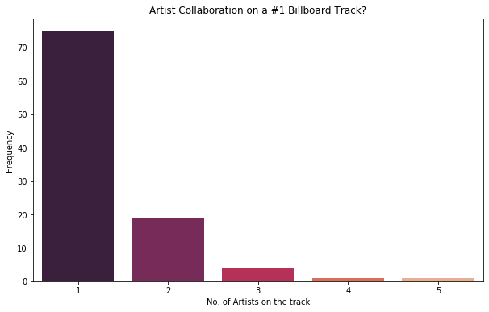

```python
f, ax = plt.subplots(figsize=(10, 6))
noPeople = artists.groupby('id').count()['artists'].value_counts()
sns.barplot(noPeople.index, noPeople.values, palette="rocket")
plt.title('Artist Collaboration on a #1 Billboard Track?')
plt.xlabel("No. of Artists on the track")
plt.ylabel("Frequency")
```

## Who were the Top Artists on the Billboard #1?

We can see here Katy Perry had a whopping 7 tracks on Billboard #1, followed by a host of other artists (Maroon 5, Justin Bieber, Bruno Mars, Adele, etc) with 4 tracks.

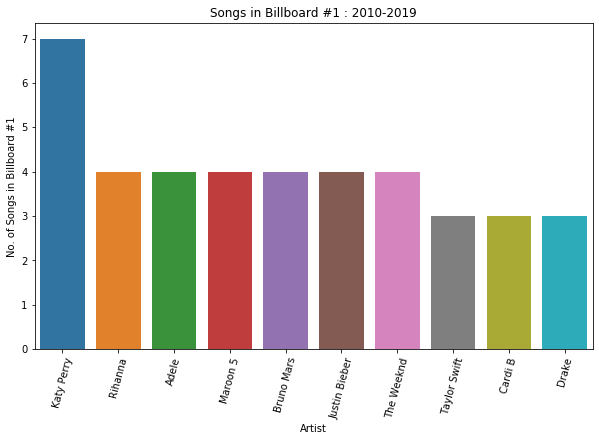

```python
f, ax = plt.subplots(figsize=(10, 6))
artistsCounts = artists.groupby('artists')['id'].count().sort_values(ascending=False)[:10]
sns.barplot(x=artistsCounts.index, y=artistsCounts.values)
plt.xticks(rotation=75)
plt.ylabel('No. of Songs in Billboard #1')
plt.xlabel('Artist')
plt.title('Songs in Billboard #1 : 2010-2019')
```

## But is Number of #1 Tracks a good measure?

We can see here that Katy Perry had 7 tracks in a short span between 2010 and 2013, but hasn't landed the #1 in the rest of the decade. You could make a claim that Katy Perry hasn't stayed relevant in the perspective of #1 Songs

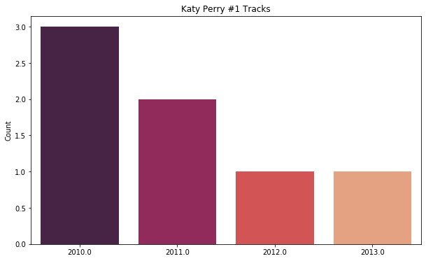

```python
f, ax = plt.subplots(figsize=(10, 6))
sns.barplot(artists[artists['artists']=="Katy Perry"]['year'].value_counts().index, artists[artists['artists']=="Katy Perry"]['year'].value_counts().values, palette="rocket")
plt.title('Katy Perry #1 Tracks')
plt.ylabel('Count')
```

## Artists - Staying Relevant

Lady Gaga tops the bar here, with Billboard #1 songs across the span of 8 years. But Maroon 5 and Bruno Mars have significantly more Top Songs (4 each) spread over 7 years. We could claim that Bruno Mars and Maroon 5 have been super reliable in rendering top of the charts songs

We can see here Katy Perry has the highest number of Top tracks, but only over three years in the Billboard charts.

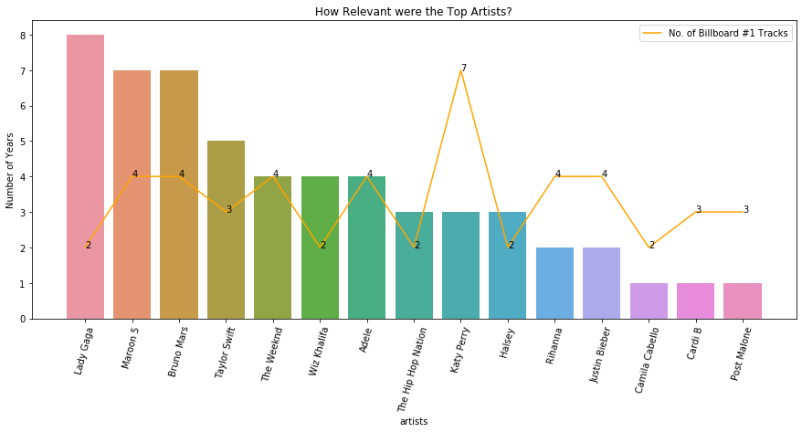

```python
adf = pd.DataFrame()
timeline = artists.groupby('artists')['year'].max() - artists.groupby('artists')['year'].min()
counts = artists.groupby('artists')['year'].count()
scores = timeline*counts/10

adf['timeline'] = timeline
adf['counts'] = counts
adf['score'] = scores
adf['artists'] = timeline.index

adf = adf.sort_values(by="timeline", ascending=False)

f, ax = plt.subplots(figsize=(15, 6))
sns.barplot(adf['artists'][:15], adf['timeline'][:15])
plt.plot(adf['artists'][:15], adf['counts'][:15], color="orange", label="No. of Billboard #1 Tracks")
plt.title('How Relevant were the Top Artists?')
plt.ylabel('Number of Years')
plt.xticks(rotation=75)
plt.legend()

for i, txt in enumerate(adf['counts'][:15]):
    ax.annotate(txt, (adf['counts'][:15].index[i], adf['counts'][:15].values[i]))
```

## Songs and Presidential Elections

**Valence** is a measure of how happy the song is on a scale of 0 to 1.

Presidential Election cycles always yield interesting results when analying time series. Here we can see that the 2016 Presidential Election, with a sharp drop, saw people listening to more sad music than ever. I'll leave the interpretation of the results to you.

```python
billyear = billDf.groupby('year').mean().reset_index()
billyear['year'] = billyear['year'].apply(int)
```

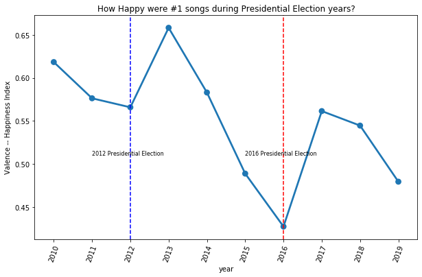

```python
f, ax = plt.subplots(figsize=(10, 6))
sns.pointplot(x="year", y="valence", data=billyear)
plt.axvline(2, linestyle='--', color='blue')
plt.axvline(6, linestyle='--', color='red')
plt.text(1,0.51, '2012 Presidential Election', color='black', fontsize=8)
plt.text(5,0.51, '2016 Presidential Election', color='black', fontsize=8)
plt.xticks(rotation=70)
plt.title('How Happy were #1 songs during Presidential Election years?')
plt.ylabel('Valence -- Happiness Index')
```

## Track Loudness

There's been a strong movement back towards music that is of lower loudness, with a -1.5 decibels drop over the decade. The previous decades saw artists competing with each other on the loudness scale, so as to be more poppy on Radio Channels. Songs that are mastered to be loud, often have poor dynamics and are not great for enjoying on good audio gear.

In addition, songs are now mastered to be played on Youtube, Apple Music and Spotify - all of which impose loudness thresholds to maximize audio quality. Thanks to the decentivizing, and an increasing preference for audio quality by consumers - tracks are becoming less loud.

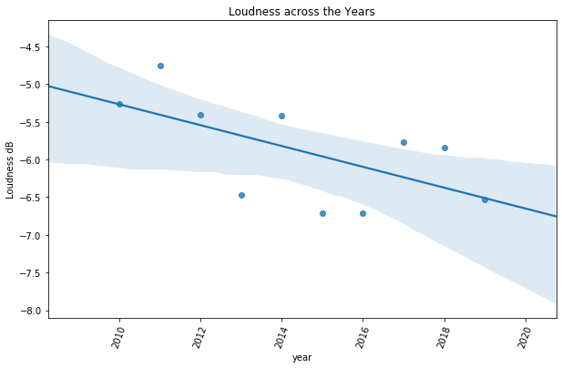

```python
f, ax = plt.subplots(figsize=(10, 6))
sns.regplot(x="year", y="loudness", data=billyear)

plt.xticks(rotation=70)
plt.title('Loudness across the Years')
plt.ylabel('Loudness dB')
```

## Drop in Energy

Spotify defines Energy as how bright and fast a song is - songs that have a lot of high frequencies - think of blaring synths, or simply singers shreaking (yikes!) - burn up pretty high on the energy spectrum.

We can see that Energy has been steadily dropping over the decade by over 25%, and has been becoming a non issue for Music Producers. Parallely, we can see that Acoustic tracks have seen a 100% lift across the decade. People are definitely liking gentler music now

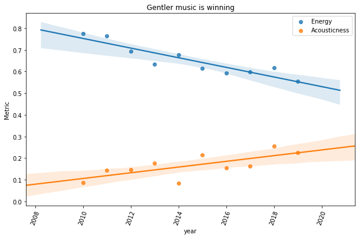

```python
f, ax = plt.subplots(figsize=(10, 6))
sns.regplot(x="year", y="energy", data=billyear, label="Energy")
sns.regplot(x="year", y="acousticness", data=billyear, label="Acousticness")
plt.legend()
plt.xticks(rotation=70)
plt.title('Gentler music is winning')
plt.ylabel('Metric')
```

## How danceable is a track?

Danceability has seen a significant upward trend across the decade, despite the Energy on a decline. People like to dance to tracks that are less energetic? How do we reconcile the differences

Let's look at tracks on both ends of the spectrum -

2010-11: Teenage Dream by Katy Perry and Rude Boy by Rihanna ruled the charts. These are high-energy tracks, with bright frequencies dominating.

2018-19: Old Town Road by Lil Nas X, Sucker by Jonas Brothers, Without Me by Halsey are all very warm and dark tracks (if one could visualize music) - but they are utterly groovy.

There was an association previously that energetic tracks are more danceable, but this decade has been gearing towards the groovy and funky above energetic pattern.

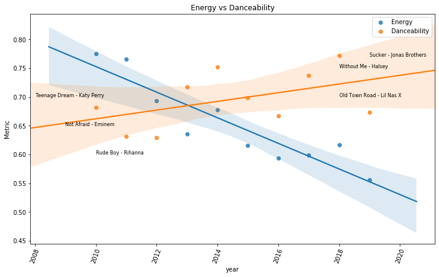

```python
f, ax = plt.subplots(figsize=(12, 7))
sns.regplot(x="year", y="energy", data=billyear, label="Energy")
sns.regplot(x="year", y="danceability", data=billyear, label="Danceability")
plt.legend()
plt.xticks(rotation=70)
plt.title('Energy vs Danceability')
plt.ylabel('Metric')
plt.text(2010,0.6, 'Rude Boy - Rihanna', color='black', fontsize=8)
plt.text(2008,0.7, 'Teenage Dream - Katy Perry', color='black', fontsize=8)
plt.text(2009,0.65, 'Not Afraid - Eminem', color='black', fontsize=8)
plt.text(2019,0.77, 'Sucker - Jonas Brothers', color='black', fontsize=8)
plt.text(2018,0.7, 'Old Town Road - Lil Nas X', color='black', fontsize=8)
plt.text(2018,0.75, 'Without Me - Halsey', color='black', fontsize=8)
```

```python
billDf[(billDf.danceability>0.7) & (billDf.energy < 0.6)].sort_values(by="year").dropna()[-5:][['song', 'artist']]
```

|  | song | artist |
| --- | --- | --- |
| 39 | Sicko Mode | Travis Scott |
| 35 | I Like It | Cardi B, Bad Bunny and J Balvin |
| 40 | Without Me | Halsey |
| 44 | Sucker | Jonas Brothers |
| 45 | Old Town Road | Lil Nas X solo or featuring Billy Ray Cyrus2 |

```python
billDf[(billDf.danceability>0.7) & (billDf.energy > 0.6)].sort_values(by="year").dropna()[:5][['song', 'artist']]
```

|  | song | artist |
| --- | --- | --- |
| 66 | Like a G6 | Far East Movement featuring The Cataracs and Dev |
| 64 | Teenage Dream | Katy Perry |
| 61 | Not Afraid | Eminem |
| 59 | Nothin' on You | B.o.B featuring Bruno Mars |
| 58 | Rude Boy | Rihanna |

## Effect of Seasons on Music Listening

```python
seasonsDf = billDf.groupby('season').agg({'valence':np.median, 'danceability':np.median, 'happy':np.mean, 'duration':np.mean})
seasonsDf['order'] = [4,2,3,1]
seasonsDf.sort_values(by="order", inplace=True)
seasonsDf
seasonsDf['valence'] = (seasonsDf['valence'] - np.mean(seasonsDf['valence']))*100/np.mean(seasonsDf['valence'])
seasonsDf['danceability'] = (seasonsDf['danceability'] - np.mean(seasonsDf['danceability']))*100/np.mean(seasonsDf['danceability'])
seasonsDf['happy'] = (seasonsDf['happy'] - np.mean(seasonsDf['happy']))*100/np.mean(seasonsDf['happy'])
seasonsDf['duration'] = (seasonsDf['duration'] - np.mean(seasonsDf['duration']))*100/np.mean(seasonsDf['duration'])
seasonsDf
```

| season | valence | danceability | happy | duration | order |
| --- | --- | --- | --- | --- | --- |
| Winter | 15.769594 | 1.291248 | 21.608980 | -4.855333 | 1 |
| Spring | -4.438149 | -1.147776 | -4.760967 | 1.678389 | 2 |
| Summer | -11.992446 | 2.582496 | -16.055339 | 0.656996 | 3 |
| Fall | 0.661001 | -2.725968 | -0.792674 | 2.519948 | 4 |

### People listen to more happy tracks during Winter

The data seems to be pointing to the idea that people like listening to more happy songs during Winter. This seems counterintuitive, but from a psychological standpoint people are more likely to be sad during Winter. Music can often function as an antidote - a happy song on a bad day can really elevate the mood. I have been looping through Feels by Calvin Harris to pump myself up and avoid the perils of the Minnesotan Winter.

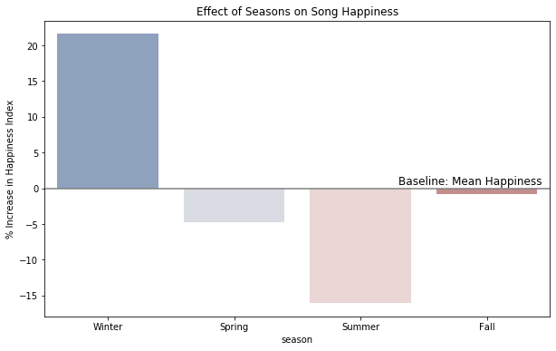

```python
f, ax = plt.subplots(figsize=(10, 6))
sns.barplot(seasonsDf.index, seasonsDf.happy, palette="vlag")
plt.title("Effect of Seasons on Song Happiness")
plt.ylabel('% Increase in Happiness Index')
plt.axhline(0, linestyle='-', color='grey')
plt.text(2.3,0.5, 'Baseline: Mean Happiness', color='black', fontsize=12)
```

## People like more 'dancy' songs in Summer

Summer has the highest number of danceable songs - and this makes sense.

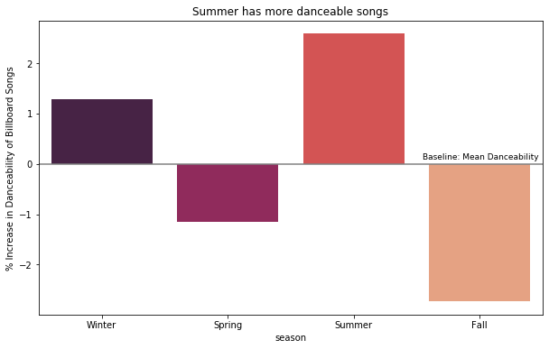

```python
f, ax = plt.subplots(figsize=(10, 6))
sns.barplot(seasonsDf.index, seasonsDf.danceability, palette="rocket")
plt.title("Summer has more danceable songs")

plt.ylabel('% Increase in Danceability of Billboard Songs')
plt.axhline(0, linestyle='-', color='grey')
plt.text(2.55,0.1, 'Baseline: Mean Danceability', color='black', fontsize=9)
```